# Mini Learning Analytics Assignment - Natural Language Processing

Renato Russo

March, 18, 2022

This is a notebook that documents my first natural language processing project. In this project, I scrape Twitter data on the war in Ukraine. I collect tweets using three different criteria:

1. **Tweets containing the term “Ukraine”**. These publications are a sort of “control group.” They are intended to measure general perceptions about the conflict, without any other filters besides time of publication and, obviously the ability and intention to publish tweets.
2. **Tweets containing the terms “Ukraine” and “CNN”**. The intent here is evaluating publications that make reference to a mainstream media outlet. This would represent one of the “control groups.”
3. **Tweets containing the terms “Ukraine” and “Breitbart”**. This would represent a sample of tweets that are associated with a right-wing website. This is the second “control group.”

```r
library(tidyverse)
```

```r
# GENERAL TWEETS FIRST DAYS ---------------------------------------------
load("/Users/renatorusso/Desktop/TLTLAB/Ukraine analysis/ukraine_feb_24.Rda")
ukr_early1 <- as_tibble(ukraine_feb_24_real)

# DATA CLEANING AND WRANGLING ---------------------------------------------
## creating a function to remove numbers and punctuation
## in preliminary analysis, I noticed that the prevalence of "Ukraine" made it
## challenging to draw any conclusion from the sentiment analysis, so I decided
## to remove it too. I'm also using the custom function to remove a few words
## detected when I ran posterior parts of this analysis

clean_text <- function(text) {
  text <- tolower(text)
  text <- gsub("[[:digit:]]+", "", text)
  text <- gsub("[[:punct:]]+", "", text)
  text <- gsub("ukraine", "", text)
  return(text)
}

## cleaning the text
ukr_early1$text <- clean_text(ukr_early1$text)

## tokenizing the words in the "text" column
tweets_token <- ukr_early1 %>%
  tidytext::unnest_tokens(word, text) %>%
  count(status_id, word)

tweets_token
```

```
## # A tibble: 297,750 x 3
##    status_id           word           n
##    <chr>               <chr>      <int>
##  1 1496680570637725697 a              1
##  2 1496680570637725697 address        1
##  3 1496680570637725697 after          1
##  4 1496680570637725697 all            1
##  5 1496680570637725697 an             2
##  6 1496680570637725697 assistance     1
##  7 1496680570637725697 cannot         1
##  8 1496680570637725697 collapse       1
##  9 1496680570637725697 constant       1
## 10 1496680570637725697 countries      1
## # … with 297,740 more rows
```

```r
## removing stop words from tidy text's standard library
tweets_token <- tweets_token %>%
  anti_join(tidytext::get_stopwords())
## removing more stop words by creating a custom list of stop words that appeared
## when I first ran posterior parts of this analysis
my_stopwords_ukr <- tibble(word = c(as.character(1:10),
                                    "like", "dont", "de", "la", "en",
                                    "amp", "et", "le", "les", "I", "à", "des", "pas",
                                    "guerre", "russie", "cest", "krieg", "breitbartnews",
                                    "cnn", "msnbc", "foxnews"))

tweets_token <- tweets_token %>%
  anti_join(my_stopwords_ukr)
## creating a document-text matrix
DTM <- tweets_token %>%
  tidytext::cast_dtm(status_id, word, n)

DTM
```

```
## <<DocumentTermMatrix (documents: 17950, terms: 34336)>>
## Non-/sparse entries: 196894/616134306
## Sparsity           : 100%
## Maximal term length: 47
## Weighting          : term frequency (tf)
```

```r
# EXPLORATORY ANALYSIS ----------------------------------------------------
## looking at the document-term matrix
tweets_token %>%
  group_by(word) %>%
  summarize(occurrence = sum(n)) %>%
  arrange(desc(occurrence))
```

```
## # A tibble: 34,336 x 2
##    word      occurrence
##    <chr>          <int>
##  1 putin           5527
##  2 russia          4886
##  3 war             2461
##  4 military        2355
##  5 russian         1805
##  6 operation       1678
##  7 people          1496
##  8 just            1285
##  9 now             1250
## 10 us              1155
## # … with 34,326 more rows
```

```r
# TOPIC MODELING ----------------------------------------------------------
library(topicmodels)
## running Latent Drichlet Allocation (LDA)
LDA <- topicmodels::LDA(DTM, k = 4, control = list(seed = 123))
LDA_td <- tidytext::tidy(LDA)
LDA_td
```

```
## # A tibble: 137,344 x 3
##    topic term            beta
##    <int> <chr>          <dbl>
##  1     1 address    1.64e- 19
##  2     2 address    3.90e- 30
##  3     3 address    2.66e-  3
##  4     4 address    1.88e- 23
##  5     1 assistance 6.80e- 18
##  6     2 assistance 2.17e-123
##  7     3 assistance 2.95e-  4
##  8     4 assistance 1.10e-  4
##  9     1 collapse   3.44e-  5
## 10     2 collapse   2.62e- 13
## # … with 137,334 more rows
```

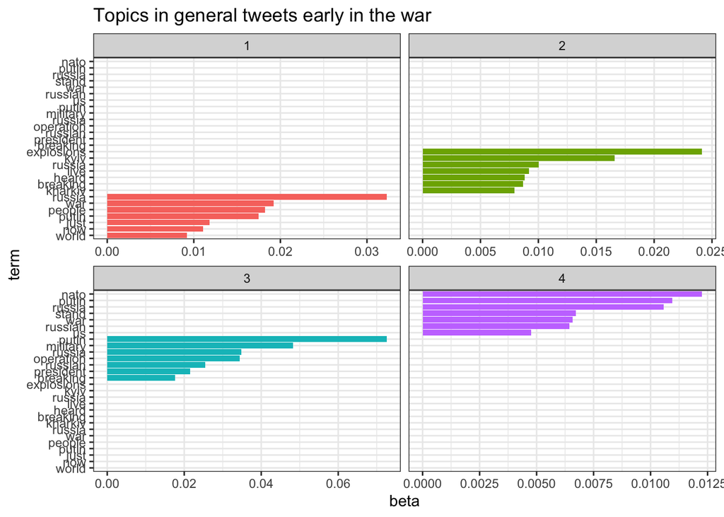

```r
## visualizing topics using ggplot2() and tidytext()
library(tidytext)

topTerms <- LDA_td %>%
  group_by(topic) %>%
  top_n(7, beta) %>%
  arrange(topic, -beta)

theme_set(theme_bw())

topTerms %>%
  mutate(term = reorder_within(term, beta, topic)) %>%
  ggplot(aes(term, beta, fill = factor(topic))) +
  geom_col(show.legend = FALSE) +
  facet_wrap(~ topic, scales = "free_x") +
  coord_flip() +
  scale_x_reordered() +
  labs(title = "Topics in general tweets early in the war")
```

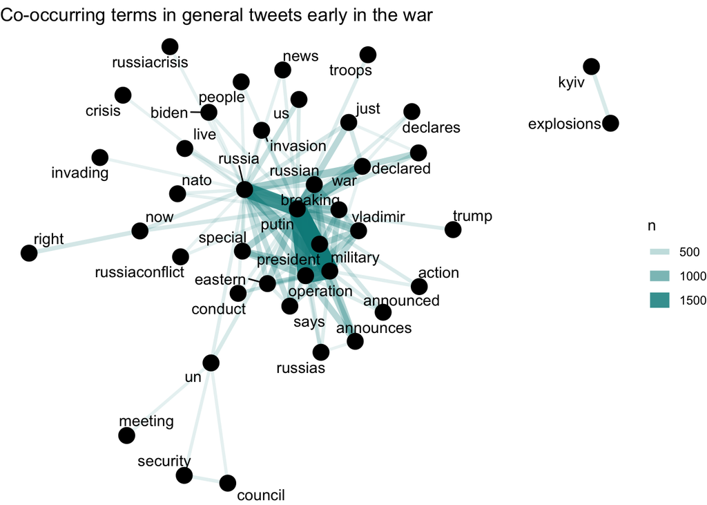

```r
library(widyr)
word_pairs_ukr_early <- tweets_token %>%
  pairwise_count(word, status_id, sort = TRUE, upper = FALSE)
#network of co-occurring words
library(ggplot2)
library(igraph)
library(ggraph)

word_pairs_ukr_early %>%
  filter(n >= 200) %>%
  graph_from_data_frame() %>%
  ggraph(layout = "fr") +
  geom_edge_link(aes(edge_alpha = n, edge_width = n), edge_colour = "cyan4") +
  geom_node_point(size = 5) +
  geom_node_text(aes(label = name), repel = TRUE,
                 point.padding = unit(0.2, "lines")) +
  theme_void() +
  labs(title = "Co-occurring terms in general tweets early in the war")
```

```r
# GENERAL TWEETS 20 DAYS INTO THE WAR ---------------------------------------------
load("/Users/renatorusso/ukraine_mar_16.Rda")
ukr_20 <- as_tibble(ukraine_mar_16)

# DATA CLEANING AND WRANGLING ---------------------------------------------

## cleaning the text
ukr_20$text <- clean_text(ukr_20$text)

## tokenizing the words in the "text" column
tweets_token_20 <- ukr_20 %>%
  tidytext::unnest_tokens(word, text) %>%
  count(status_id, word)

## removing stop words from tidy text's standard library
tweets_token_20 <- tweets_token_20 %>%
  anti_join(stop_words)
## words in German and French have not been removed with the "stop_words" native
## dataset (and they appear a lot), so I'll try to include the word databases
## "manually"
stop_german <- data.frame(word = stopwords::stopwords("de"), stringsAsFactors = FALSE)

stop_french <- data.frame(word = stopwords::stopwords("fr"), stringsAsFactors = FALSE)

tweets_token_20 <-  tweets_token_20 %>%
  anti_join(stop_words, by = c('word')) %>%
  anti_join(stop_german, by = c("word")) %>%
  anti_join(stop_french, by = c("word"))

tweets_token_20 <- tweets_token_20 %>%
  anti_join(my_stopwords_ukr)
## creating a document-text matrix
DTM_20 <- tweets_token_20 %>%
  tidytext::cast_dtm(status_id, word, n)

# EXPLORATORY ANALYSIS ----------------------------------------------------
## looking at the document-term matrix
tweets_token_20 %>%
  group_by(word) %>%
  summarize(occurrence = sum(n)) %>%
  arrange(desc(occurrence))
```

```
## # A tibble: 54,146 x 2
##    word     occurrence
##    <chr>         <int>
##  1 russia         3682
##  2 russian        2502
##  3 putin          2309
##  4 people         1631
##  5 nato           1243
##  6 biden           985
##  7 stop            954
##  8 world           881
##  9 military        874
## 10 children        824
## # … with 54,136 more rows
```

```r
# TOPIC MODELING ----------------------------------------------------------
#library(topicmodels)
## running Latent Drichlet Allocation (LDA)
LDA_20 <- topicmodels::LDA(DTM_20, k = 4, control = list(seed = 123))
LDA_td_20 <- tidytext::tidy(LDA_20)
LDA_td_20
```

```
## # A tibble: 216,584 x 3
##    topic term          beta
##    <int> <chr>        <dbl>
##  1     1 americans 8.47e- 4
##  2     2 americans 3.49e-19
##  3     3 americans 9.69e- 4
##  4     4 americans 5.77e- 4
##  5     1 anymore   8.56e- 5
##  6     2 anymore   3.65e- 8
##  7     3 anymore   5.97e-11
##  8     4 anymore   2.53e- 4
##  9     1 army      4.75e- 4
## 10     2 army      7.63e- 4
## # … with 216,574 more rows
```

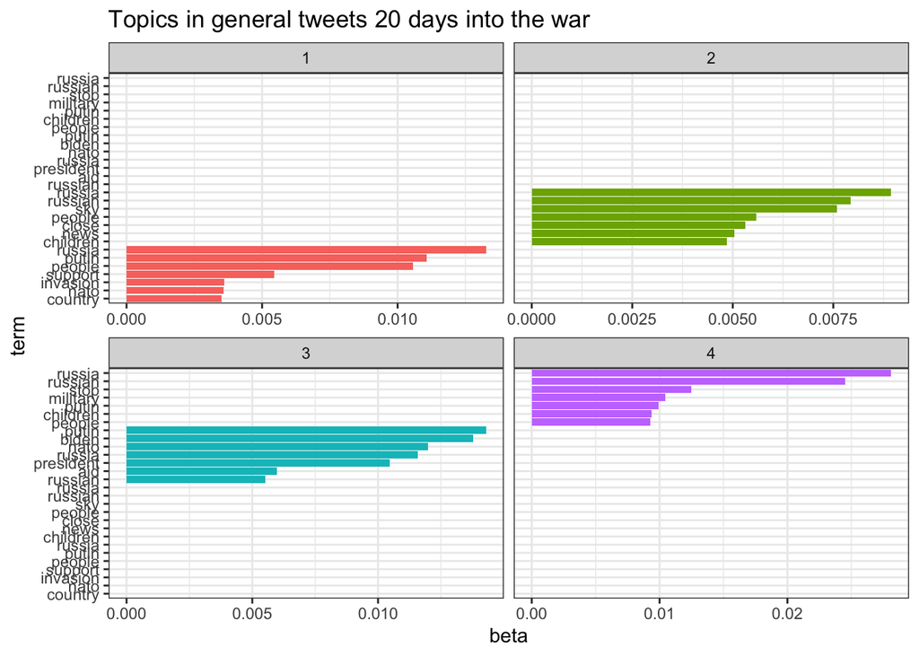

```r
topTerms_20 <- LDA_td_20 %>%
  group_by(topic) %>%
  top_n(7, beta) %>%
  arrange(topic, -beta)

topTerms_20 %>%
  mutate(term = reorder_within(term, beta, topic)) %>%
  ggplot(aes(term, beta, fill = factor(topic))) +
  geom_col(show.legend = FALSE) +
  facet_wrap(~ topic, scales = "free_x") +
  coord_flip() +
  scale_x_reordered() +
  labs(title = "Topics in general tweets 20 days into the war")
```

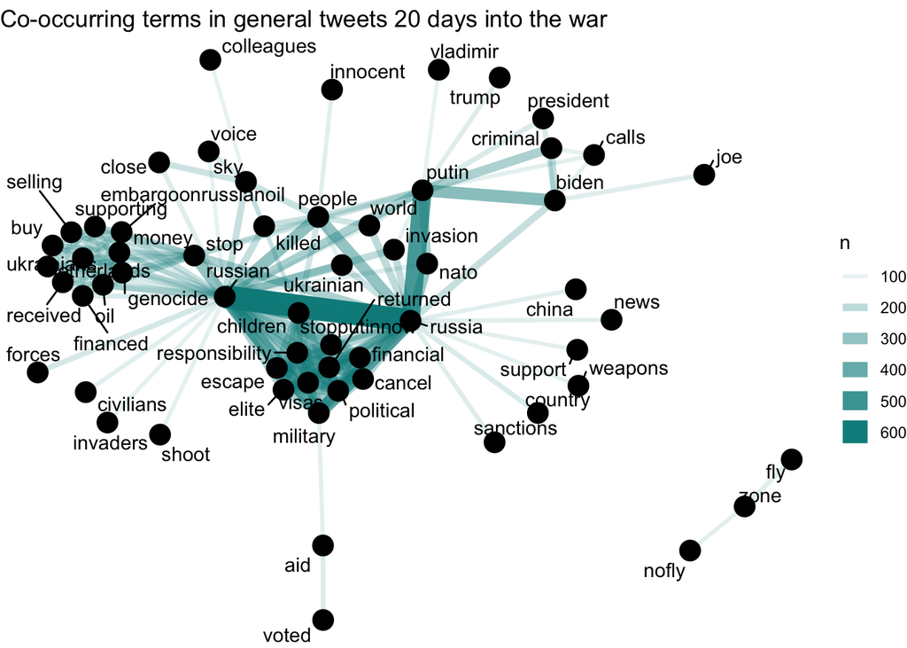

```r
word_pairs_ukr_20 <- tweets_token_20 %>%
  pairwise_count(word, status_id, sort = TRUE, upper = FALSE)

#network of co-occurring words
word_pairs_ukr_20 %>%
  filter(n >= 100) %>%
  graph_from_data_frame() %>%
  ggraph(layout = "fr") +
  geom_edge_link(aes(edge_alpha = n, edge_width = n), edge_colour = "cyan4") +
  geom_node_point(size = 5) +
  geom_node_text(aes(label = name), repel = TRUE,
                 point.padding = unit(0.2, "lines")) +
  theme_void() +
  labs(title = "Co-occurring terms in general tweets 20 days into the war")
```

```r
# CNN-RELATED EARLY TWEETS ---------------------------------------------
load("/Users/renatorusso/Desktop/TLTLAB/Ukraine analysis/ukraine_cnn_feb_25.Rda")
ukr_early_cnn <- as_tibble(ukraine_cnn_feb_25)

# DATA CLEANING AND WRANGLING ---------------------------------------------

## cleaning the text
ukr_early_cnn$text <- clean_text(ukr_early_cnn$text)

## tokenizing the words in the "text" column
tweets_token_cnn_early <- ukr_early_cnn %>%
  tidytext::unnest_tokens(word, text) %>%
  count(status_id, word)

## removing stop words from tidy text's standard library
tweets_token_cnn_early <- tweets_token_cnn_early %>%
  anti_join(stop_words)
tweets_token_cnn_early <-  tweets_token_cnn_early %>%
  anti_join(stop_words, by = c('word')) %>%
  anti_join(stop_german, by = c("word")) %>%
  anti_join(stop_french, by = c("word"))

tweets_token_cnn_early <- tweets_token_cnn_early %>%
  anti_join(my_stopwords_ukr)
## creating a document-text matrix
DTM_early_cnn <- tweets_token_cnn_early %>%
  tidytext::cast_dtm(status_id, word, n)

# EXPLORATORY ANALYSIS ----------------------------------------------------
## looking at the document-term matrix
tweets_token_cnn_early %>%
  group_by(word) %>%
  summarize(occurrence = sum(n)) %>%
  arrange(desc(occurrence))
```

```
## # A tibble: 42,327 x 2
##    word      occurrence
##    <chr>          <int>
##  1 russia          4863
##  2 russian         3073
##  3 putin           2575
##  4 invasion        1793
##  5 ukrainian       1693
##  6 nato            1523
##  7 biden           1471
##  8 world           1132
##  9 kyiv            1074
## 10 people          1051
## # … with 42,317 more rows
```

```r
# TOPIC MODELING ----------------------------------------------------------
#library(topicmodels)
## running Latent Drichlet Allocation (LDA)
LDA_cnn_early <- topicmodels::LDA(DTM_early_cnn, k = 4, control = list(seed = 123))
LDA_cnn_early_td <- tidytext::tidy(LDA_cnn_early)
LDA_cnn_early
```

```
## A LDA_VEM topic model with 4 topics.
```

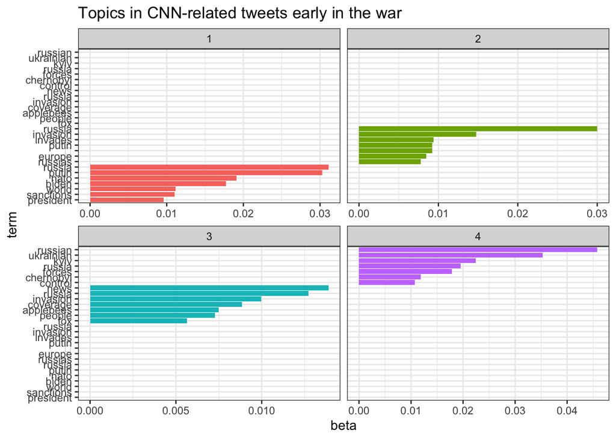

```r
topTerms_cnn_early <- LDA_cnn_early_td %>%
  group_by(topic) %>%
  top_n(7, beta) %>%
  arrange(topic, -beta)

topTerms_cnn_early %>%
  mutate(term = reorder_within(term, beta, topic)) %>%
  ggplot(aes(term, beta, fill = factor(topic))) +
  geom_col(show.legend = FALSE) +
  facet_wrap(~ topic, scales = "free_x") +
  coord_flip() +
  scale_x_reordered() +
  labs(title = "Topics in CNN-related tweets early in the war")
```

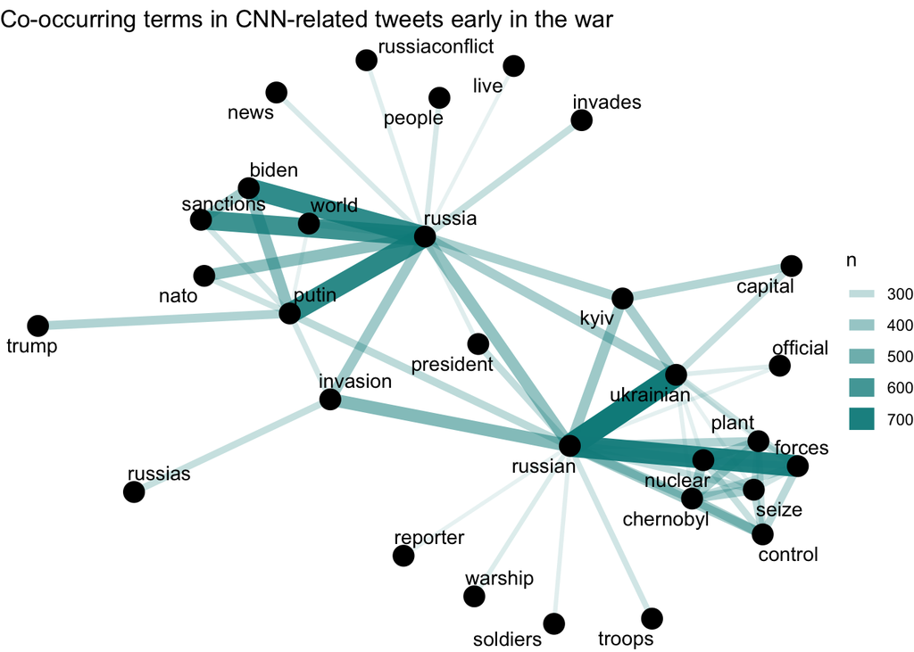

```r
word_pairs_cnn_early <- tweets_token_cnn_early %>%
  pairwise_count(word, status_id, sort = TRUE, upper = FALSE)

## network of co-occurring words
word_pairs_cnn_early %>%
  filter(n >= 200) %>%
  graph_from_data_frame() %>%
  ggraph(layout = "fr") +
  geom_edge_link(aes(edge_alpha = n, edge_width = n), edge_colour = "cyan4") +
  geom_node_point(size = 5) +
  geom_node_text(aes(label = name), repel = TRUE,
                 point.padding = unit(0.2, "lines")) +
  theme_void() +
  labs(title = "Co-occurring terms in CNN-related tweets early in the war")
```

```r
# CNN-RELATED 20 DAYS INTO THE WAR ---------------------------------------------
load("/Users/renatorusso/ukraine_cnn_mar_16.Rda")
ukr_d20_cnn <- as_tibble(ukraine_cnn_mar_16)

# DATA CLEANING AND WRANGLING ---------------------------------------------

## cleaning the text
ukr_d20_cnn$text <- clean_text(ukr_d20_cnn$text)

## tokenizing the words in the "text" column
tweets_token_d20_cnn <- ukr_d20_cnn %>%
  tidytext::unnest_tokens(word, text) %>%
  count(status_id, word)

## removing stop words from tidy text's standard library
tweets_token_d20_cnn <- tweets_token_d20_cnn %>%
  anti_join(stop_words)
tweets_token_d20_cnn <-  tweets_token_d20_cnn %>%
  anti_join(stop_words, by = c('word')) %>%
  anti_join(stop_german, by = c("word")) %>%
  anti_join(stop_french, by = c("word"))

tweets_token_d20_cnn <- tweets_token_d20_cnn %>%
  anti_join(my_stopwords_ukr)
## creating a document-text matrix
DTM_d20_cnn <- tweets_token_d20_cnn %>%
  tidytext::cast_dtm(status_id, word, n)

# EXPLORATORY ANALYSIS ----------------------------------------------------
## looking at the document-term matrix
tweets_token_d20_cnn %>%
  group_by(word) %>%
  summarize(occurrence = sum(n)) %>%
  arrange(desc(occurrence))
```

```
## # A tibble: 41,410 x 2
##    word      occurrence
##    <chr>          <int>
##  1 russia          3978
##  2 russian         2809
##  3 putin           2413
##  4 nato            1704
##  5 news            1251
##  6 ukrainian       1137
##  7 biden           1117
##  8 military        1088
##  9 zelensky        1080
## 10 people          1077
## # … with 41,400 more rows
```

```r
# TOPIC MODELING ----------------------------------------------------------
#library(topicmodels)
## running Latent Drichlet Allocation (LDA)
LDA_d20_cnn <- topicmodels::LDA(DTM_d20_cnn, k = 4, control = list(seed = 123))
LDA_d20_cnn_td <- tidytext::tidy(LDA_d20_cnn)
LDA_d20_cnn
```

```
## A LDA_VEM topic model with 4 topics.
```

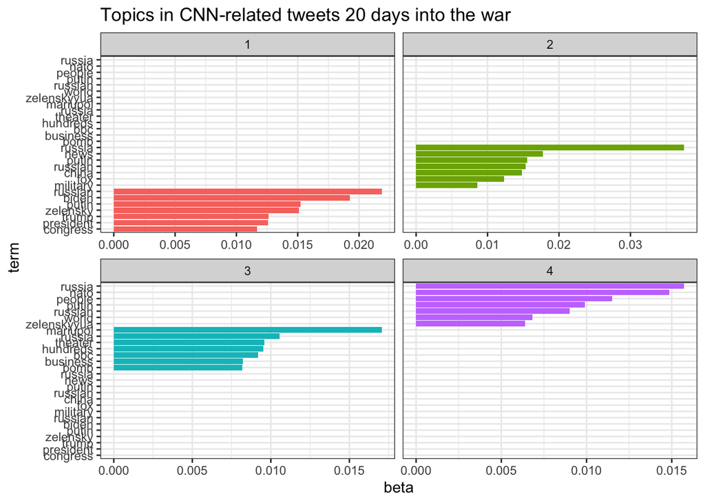

```r
topTerms_d20_cnn <- LDA_d20_cnn_td %>%
  group_by(topic) %>%
  top_n(7, beta) %>%
  arrange(topic, -beta)

topTerms_d20_cnn %>%
  mutate(term = reorder_within(term, beta, topic)) %>%
  ggplot(aes(term, beta, fill = factor(topic))) +
  geom_col(show.legend = FALSE) +
  facet_wrap(~ topic, scales = "free_x") +
  coord_flip() +
  scale_x_reordered() +
  labs(title = "Topics in CNN-related tweets 20 days into the war")
```

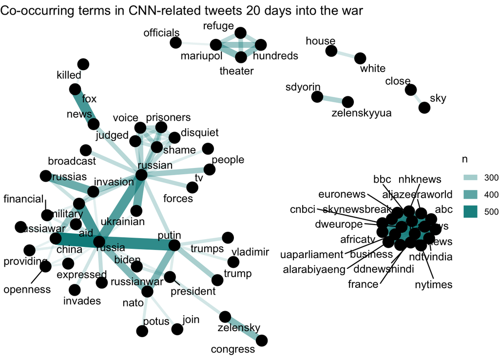

```r
word_pairs_d20_cnn <- tweets_token_d20_cnn %>%
  pairwise_count(word, status_id, sort = TRUE, upper = FALSE)

## network of co-occurring words
word_pairs_d20_cnn %>%
  filter(n >= 200) %>%
  graph_from_data_frame() %>%
  ggraph(layout = "fr") +
  geom_edge_link(aes(edge_alpha = n, edge_width = n), edge_colour = "cyan4") +
  geom_node_point(size = 5) +
  geom_node_text(aes(label = name), repel = TRUE,
                 point.padding = unit(0.2, "lines")) +
  theme_void() +
  labs(title = "Co-occurring terms in CNN-related tweets 20 days into the war")
```

```r
# BREITBART-RELATED EARLY TWEETS ---------------------------------------------
load("/Users/renatorusso/Desktop/TLTLAB/Ukraine analysis/ukraine_bb_feb_25.Rda")
ukr_early_bb <- as_tibble(ukraine_bb_feb_25)

# DATA CLEANING AND WRANGLING ---------------------------------------------

## cleaning the text
ukr_early_bb$text <- clean_text(ukr_early_bb$text)

## tokenizing the words in the "text" column
tweets_token_bb_early <- ukr_early_bb %>%
  tidytext::unnest_tokens(word, text) %>%
  count(status_id, word)

## removing stop words from tidy text's standard library
tweets_token_bb_early <- tweets_token_bb_early %>%
  anti_join(stop_words)
tweets_token_bb_early <-  tweets_token_bb_early %>%
  anti_join(stop_words, by = c('word')) %>%
  anti_join(stop_german, by = c("word")) %>%
  anti_join(stop_french, by = c("word"))

tweets_token_bb_early <- tweets_token_bb_early %>%
  anti_join(my_stopwords_ukr)
## creating a document-text matrix
DTM_early_bb <- tweets_token_bb_early %>%
  tidytext::cast_dtm(status_id, word, n)

# EXPLORATORY ANALYSIS ----------------------------------------------------
## looking at the document-term matrix
tweets_token_bb_early %>%
  group_by(word) %>%
  summarize(occurrence = sum(n)) %>%
  arrange(desc(occurrence))
```

```
## # A tibble: 3,944 x 2
##    word      occurrence
##    <chr>          <int>
##  1 russia           355
##  2 biden            350
##  3 putin            330
##  4 invasion         201
##  5 trump            192
##  6 joe              162
##  7 russian          133
##  8 sanctions        133
##  9 crisis           126
## 10 america          107
## # … with 3,934 more rows
```

```r
# TOPIC MODELING ----------------------------------------------------------
#library(topicmodels)
## running Latent Drichlet Allocation (LDA)
LDA_bb_early <- topicmodels::LDA(DTM_early_bb, k = 4, control = list(seed = 123))
LDA_bb_early_td <- tidytext::tidy(LDA_bb_early)
LDA_bb_early
```

```
## A LDA_VEM topic model with 4 topics.
```

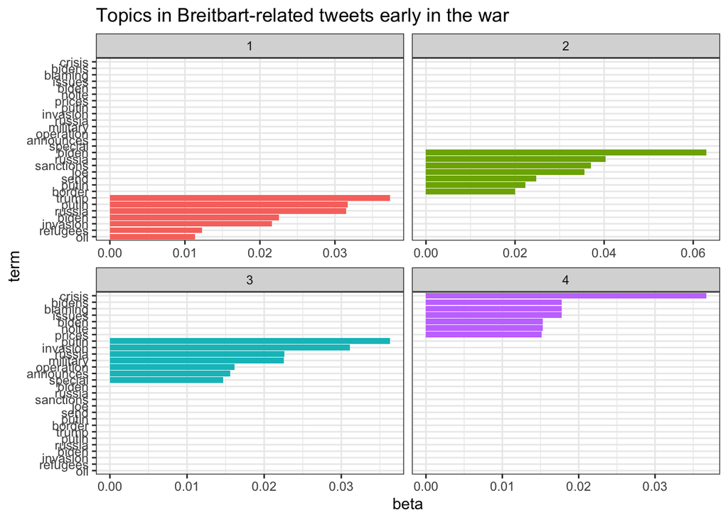

```r
topTerms_bb_early <- LDA_bb_early_td %>%
  group_by(topic) %>%
  top_n(7, beta) %>%
  arrange(topic, -beta)

topTerms_bb_early %>%
  mutate(term = reorder_within(term, beta, topic)) %>%
  ggplot(aes(term, beta, fill = factor(topic))) +
  geom_col(show.legend = FALSE) +
  facet_wrap(~ topic, scales = "free_x") +
  coord_flip() +
  scale_x_reordered() +
  labs(title = "Topics in Breitbart-related tweets early in the war")
```

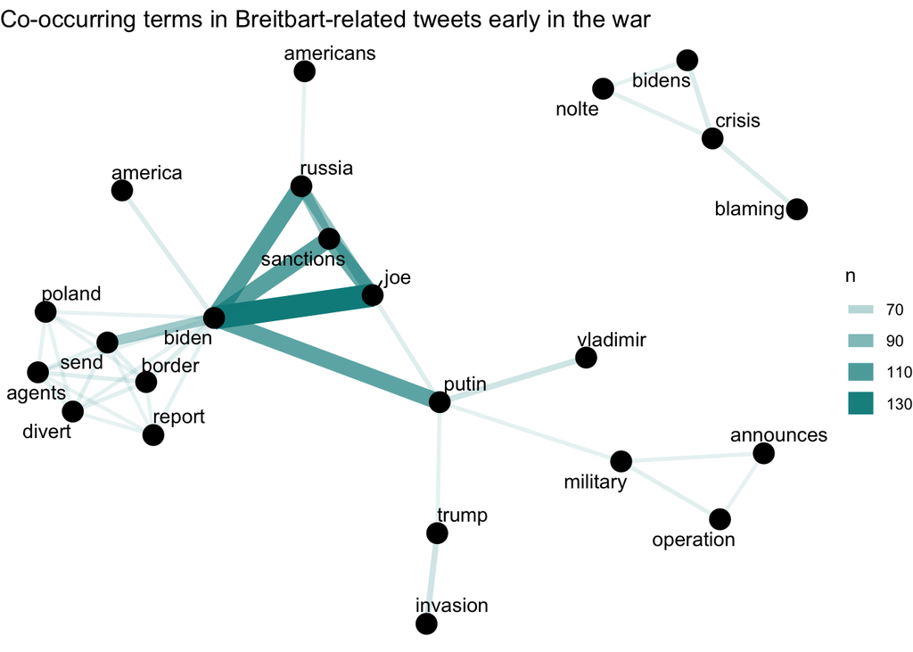

```r
word_pairs_bb_early <- tweets_token_bb_early %>%
  pairwise_count(word, status_id, sort = TRUE, upper = FALSE)

## network of co-occurring words
word_pairs_bb_early %>%
  filter(n >= 50) %>%
  graph_from_data_frame() %>%
  ggraph(layout = "fr") +
  geom_edge_link(aes(edge_alpha = n, edge_width = n), edge_colour = "cyan4") +
  geom_node_point(size = 5) +
  geom_node_text(aes(label = name), repel = TRUE,
                 point.padding = unit(0.2, "lines")) +
  theme_void() +
  labs(title = "Co-occurring terms in Breitbart-related tweets early in the war")
```

```r
# BREITBART-RELATED 20 DAYS INTO THE WAR TWEETS ---------------------------------------------
load("/Users/renatorusso/ukraine_bb_mar_16.Rda")
ukr_d20_bb <- as_tibble(ukraine_bb_mar_16)

# DATA CLEANING AND WRANGLING ---------------------------------------------

## cleaning the text
ukr_d20_bb$text <- clean_text(ukr_d20_bb$text)

## tokenizing the words in the "text" column
tweets_token_d20_bb <- ukr_d20_bb %>%
  tidytext::unnest_tokens(word, text) %>%
  count(status_id, word)

## removing stop words from tidy text's standard library
tweets_token_d20_bb <- tweets_token_d20_bb %>%
  anti_join(stop_words)
tweets_token_d20_bb <-  tweets_token_d20_bb %>%
  anti_join(stop_words, by = c('word')) %>%
  anti_join(stop_german, by = c("word")) %>%
  anti_join(stop_french, by = c("word"))

tweets_token_d20_bb <- tweets_token_d20_bb %>%
  anti_join(my_stopwords_ukr)
## creating a document-text matrix
DTM_d20_bb <- tweets_token_d20_bb %>%
  tidytext::cast_dtm(status_id, word, n)

# EXPLORATORY ANALYSIS ----------------------------------------------------
## looking at the document-term matrix
tweets_token_d20_bb %>%
  group_by(word) %>%
  summarize(occurrence = sum(n)) %>%
  arrange(desc(occurrence))
```

```
## # A tibble: 3,459 x 2
##    word      occurrence
##    <chr>          <int>
##  1 russia           242
##  2 biden            130
##  3 invasion         103
##  4 putin            102
##  5 russian          102
##  6 trump             96
##  7 china             90
##  8 poll              72
##  9 president         61
## 10 invaded           55
## # … with 3,449 more rows
```

```r
# TOPIC MODELING ----------------------------------------------------------
#library(topicmodels)
## running Latent Drichlet Allocation (LDA)
LDA_d20_bb <- topicmodels::LDA(DTM_d20_bb, k = 4, control = list(seed = 123))
LDA_d20_bb_td <- tidytext::tidy(LDA_d20_bb)
LDA_d20_bb
```

```
## A LDA_VEM topic model with 4 topics.
```

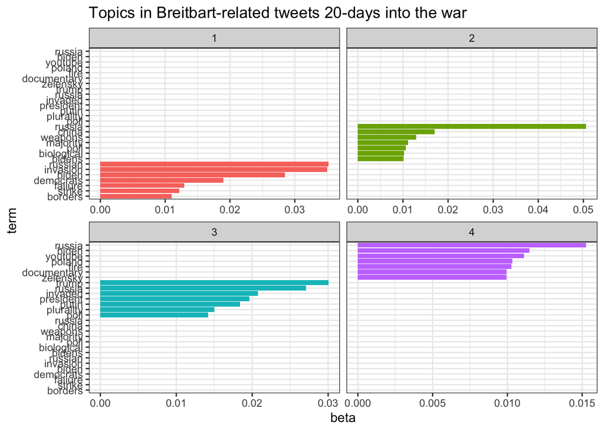

```r
topTerms_d20_bb <- LDA_d20_bb_td %>%
  group_by(topic) %>%
  top_n(7, beta) %>%
  arrange(topic, -beta)

topTerms_d20_bb %>%
  mutate(term = reorder_within(term, beta, topic)) %>%
  ggplot(aes(term, beta, fill = factor(topic))) +
  geom_col(show.legend = FALSE) +
  facet_wrap(~ topic, scales = "free_x") +
  coord_flip() +
  scale_x_reordered() +
  labs(title = "Topics in Breitbart-related tweets 20-days into the war")
```

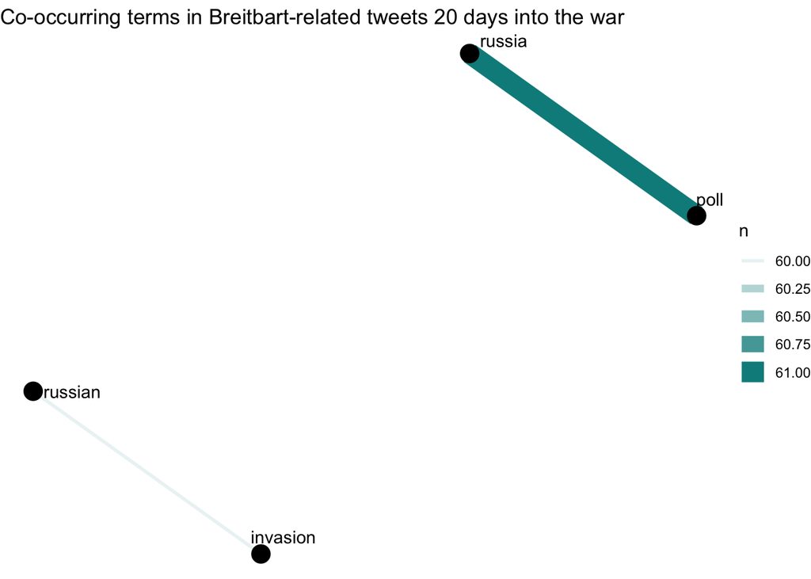

```r
word_pairs_d20_bb <- tweets_token_d20_bb %>%
  pairwise_count(word, status_id, sort = TRUE, upper = FALSE)

## network of co-occurring words
word_pairs_d20_bb %>%
  filter(n >= 50) %>%
  graph_from_data_frame() %>%
  ggraph(layout = "fr") +
  geom_edge_link(aes(edge_alpha = n, edge_width = n), edge_colour = "cyan4") +
  geom_node_point(size = 5) +
  geom_node_text(aes(label = name), repel = TRUE,
                 point.padding = unit(0.2, "lines")) +
  theme_void() +
  labs(title = "Co-occurring terms in Breitbart-related tweets 20 days into the war")
```